# Fabre Museum Project: Statistical Analysis

Amélie Goubé

2026-05-12

# 1. Data Preparation

We import the cleaned dataset and format the grouping variable (sex).

```r
# Importing the cleaned file from Python
df <- read.csv("data/data_clean.csv", sep = ";")
# Quick chek
str(df)
```

```
## 'data.frame':    10 obs. of  11 variables:
##  $ sex                         : chr  "f" "g" "f" "g" ...
##  $ number_of_zones_explored    : num  8 8 0 0 4 4 NA NA 9 9
##  $ distance_travelled          : int  300 300 300 300 300 300 300 300 300 300
##  $ movement_autonomy           : int  0 1 1 1 1 1 0 0 0 0
##  $ orientation_towards_artwork : int  2 1 1 1 2 2 1 2 2 1
##  $ postural_adjustment         : int  1 2 2 1 0 2 1 2 2 5
##  $ physical_approach           : num  0 0 0 0 0 0 0 1 NA NA
##  $ overall_motor_engagement    : int  0 1 2 1 1 1 1 1 1 2
##  $ interaction_with_environment: int  2 2 2 1 1 0 1 1 1 1
##  $ interaction_with_peers      : int  1 1 0 0 1 1 0 0 2 1
##  $ interaction_with_adults     : num  1 0 2 2 0 0 1 0 NA NA
```

```r
# Converting 'sex' into a factor to define the comparison groups
df$sex <- factor(df$sex,
                 levels = c("f", "g"),
                 labels = c("Girls", "Boys"))
```

# 2. Normality Assessment

Before choosing between a Parametric (T-test) or Non-Parametric (Wilcoxon) test, we check the distribution of each variable using the Shapiro-Wilk test.

```r
# List of behaviors to analyze
behavioral_vars <- c("number_of_zones_explored", "movement_autonomy",
                     "orientation_towards_artwork", "postural_adjustment",
                     "physical_approach", "overall_motor_engagement",
                     "interaction_with_environment", "interaction_with_peers",
                     "interaction_with_adults")

# Using a loop here to avoid copy-pasting the same code for every single variable
for (var in behavioral_vars) {
  cat("\n\n### Analyzing behavior:", var, "\n")


  # Checking for normality (Shapiro-Wilk test)
  # Using na.omit so the code doesn't crash if there are empty cells (NAs)
  shapiro_res <- shapiro.test(na.omit(df[[var]]))
  print(shapiro_res)
}
```

```
##
##
## ### Analyzing behavior: number_of_zones_explored
##
##  Shapiro-Wilk normality test
##
## data:  na.omit(df[[var]])
## W = 0.83728, p-value = 0.07061
##
##
##
## ### Analyzing behavior: movement_autonomy
##
##  Shapiro-Wilk normality test
##
## data:  na.omit(df[[var]])
## W = 0.65527, p-value = 0.000254
##
##
##
## ### Analyzing behavior: orientation_towards_artwork
##
##  Shapiro-Wilk normality test
##
## data:  na.omit(df[[var]])
## W = 0.65527, p-value = 0.000254
##
##
##
## ### Analyzing behavior: postural_adjustment
##
##  Shapiro-Wilk normality test
##
## data:  na.omit(df[[var]])
## W = 0.8009, p-value = 0.01487
##
##
##
## ### Analyzing behavior: physical_approach
##
```

[output cut: 25 more lines]

```
## ### Analyzing behavior: interaction_with_peers
##
##  Shapiro-Wilk normality test
##
## data:  na.omit(df[[var]])
## W = 0.80218, p-value = 0.01541
##
##
##
## ### Analyzing behavior: interaction_with_adults
##
##  Shapiro-Wilk normality test
##
## data:  na.omit(df[[var]])
## W = 0.78233, p-value = 0.01846
```

# 3. Gender Comparison: Girls vs. Boys

Since most variables are non-normal (p < 0.05) and our sample size is small (n=10),the Wilcoxon Rank Sum test is the most robust choice.

```
##
##
## ### Analyzing behavior: number_of_zones_explored
##
##  Shapiro-Wilk normality test
##
## data:  na.omit(df[[var]])
## W = 0.83728, p-value = 0.07061
```

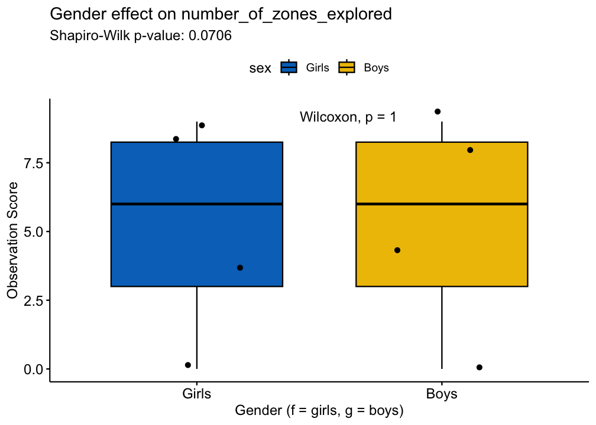

```
##
##
## ### Analyzing behavior: movement_autonomy
##
##  Shapiro-Wilk normality test
##
## data:  na.omit(df[[var]])
## W = 0.65527, p-value = 0.000254
```

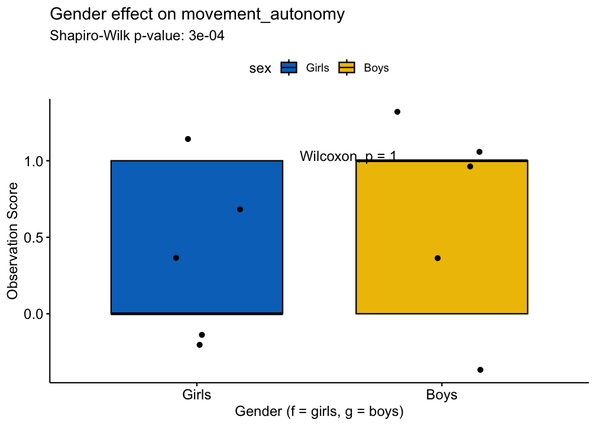

```
##
##
## ### Analyzing behavior: orientation_towards_artwork
##
##  Shapiro-Wilk normality test
##
## data:  na.omit(df[[var]])
## W = 0.65527, p-value = 0.000254
```

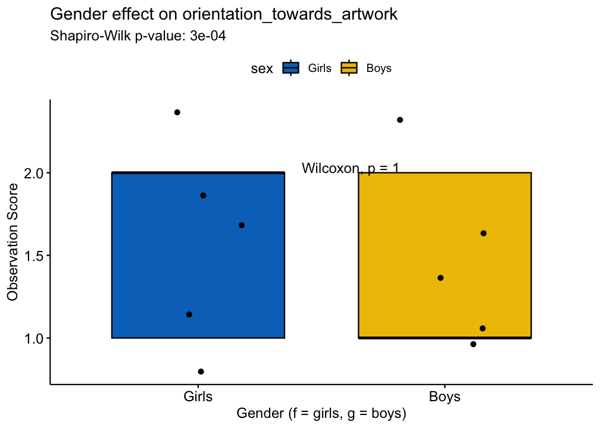

```
##
##
## ### Analyzing behavior: postural_adjustment
##
##  Shapiro-Wilk normality test
##
## data:  na.omit(df[[var]])
## W = 0.8009, p-value = 0.01487
```

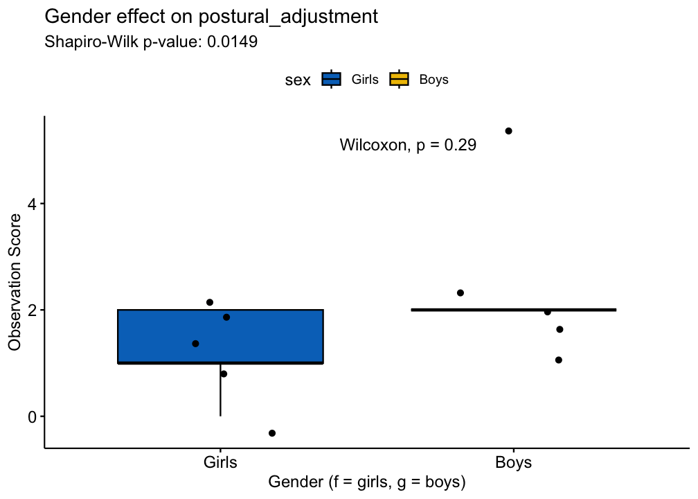

```
##
##
## ### Analyzing behavior: physical_approach
##
##  Shapiro-Wilk normality test
##
## data:  na.omit(df[[var]])
## W = 0.4184, p-value = 1.047e-06
```

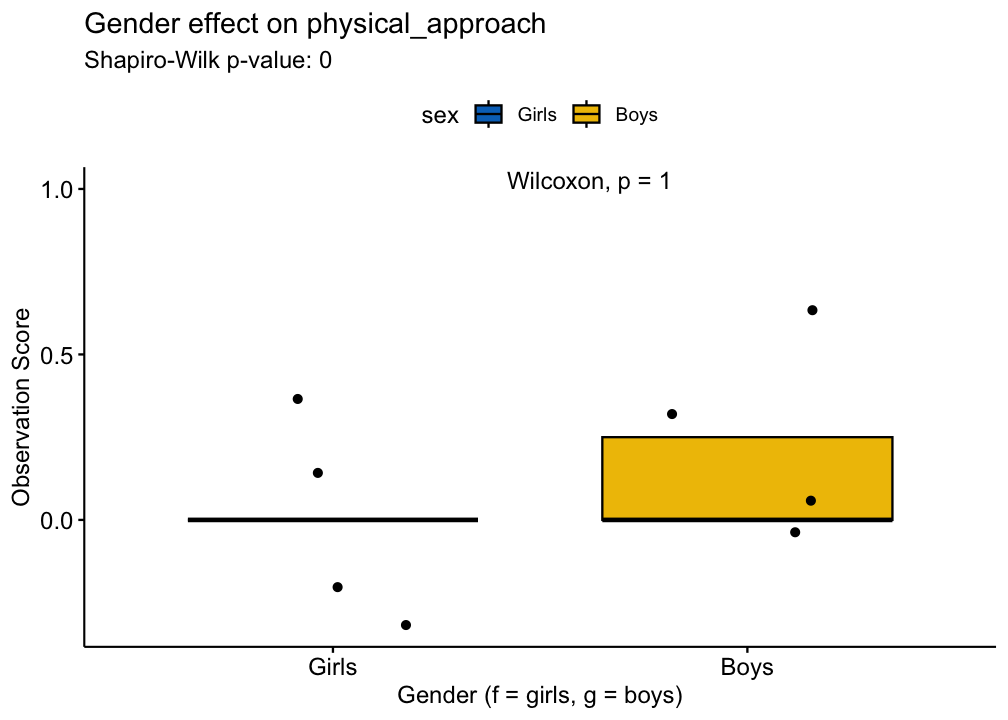

```
##
##
## ### Analyzing behavior: overall_motor_engagement
##
##  Shapiro-Wilk normality test
##
## data:  na.omit(df[[var]])
## W = 0.75164, p-value = 0.003737
```

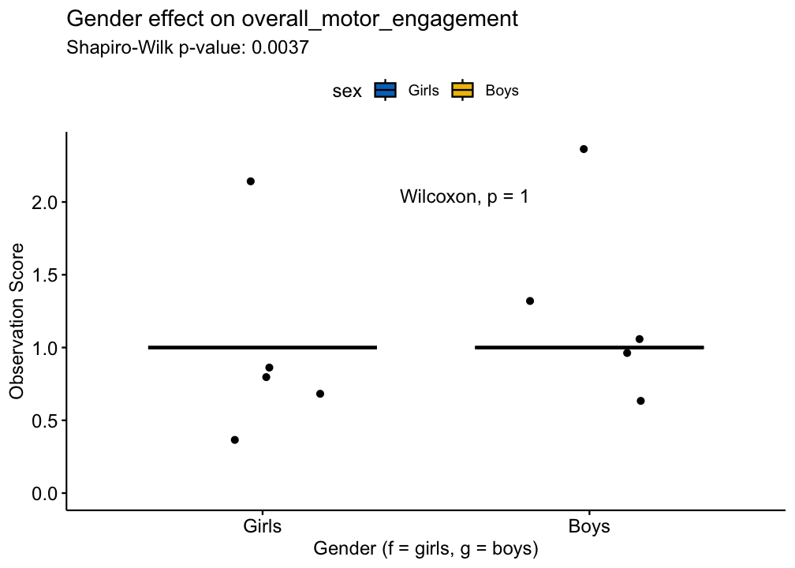

```
##
##
## ### Analyzing behavior: interaction_with_environment
##
##  Shapiro-Wilk normality test
##
## data:  na.omit(df[[var]])
## W = 0.79406, p-value = 0.01228
```

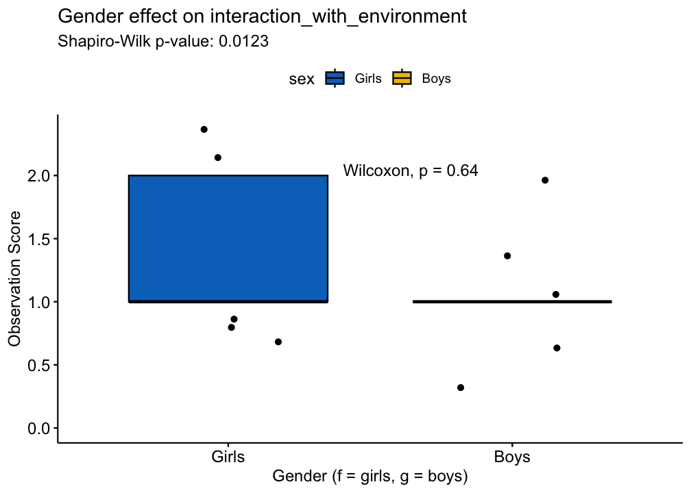

```
##
##
## ### Analyzing behavior: interaction_with_peers
##
##  Shapiro-Wilk normality test
##
## data:  na.omit(df[[var]])
## W = 0.80218, p-value = 0.01541
```

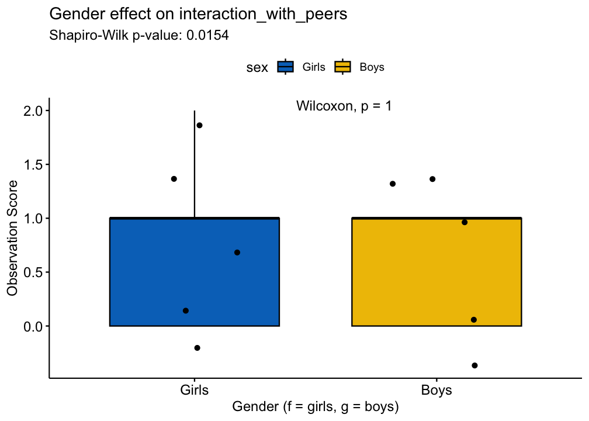

```
##
##
## ### Analyzing behavior: interaction_with_adults
##
##  Shapiro-Wilk normality test
##
## data:  na.omit(df[[var]])
## W = 0.78233, p-value = 0.01846
```

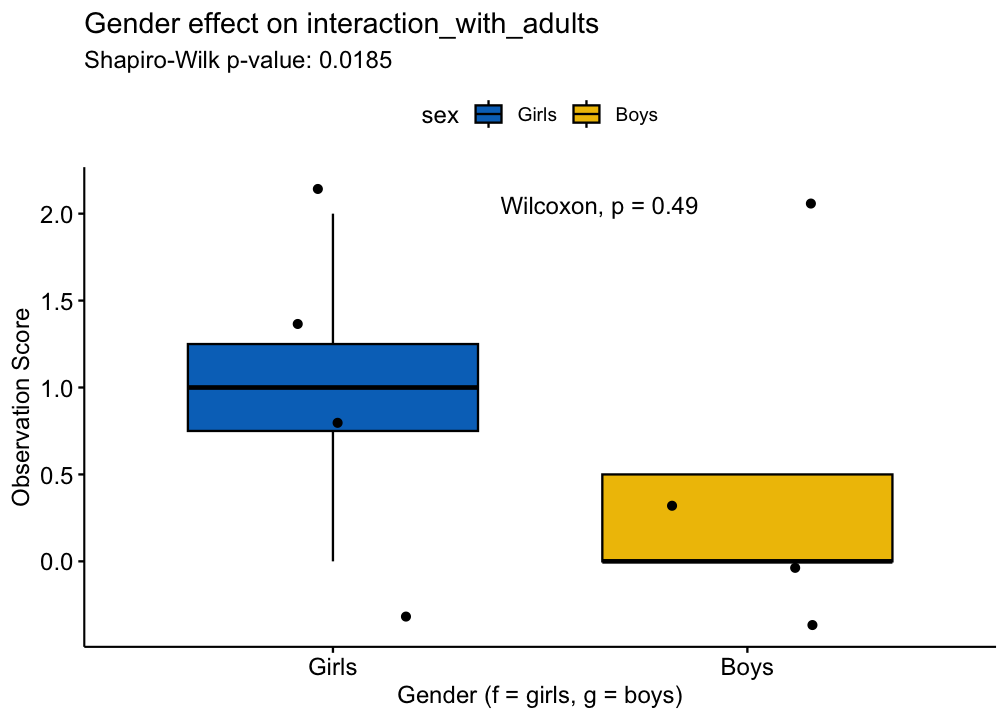

```r
# Creating the comparison plot
for (var in behavioral_vars) {

  # Print a header for each variable in the report
  cat("\n\n### Analyzing behavior:", var, "\n")

  # Normality Check (Shapiro-Wilk Test)
  # We use na.omit to handle missing data (NAs) so the test doesn't fail.
  shapiro_res <- shapiro.test(na.omit(df[[var]]))
  print(shapiro_res)

  # Visualizing and Comparing Groups
p <- ggboxplot(df, x = "sex", y = var,
               fill = "sex",
               palette = "jco",
               add = "jitter",
               na.rm = TRUE,
               title = paste("Gender effect on", var),
               subtitle = paste("Shapiro-Wilk p-value:", round(shapiro_res$p.value, 4)),
               ylab = "Observation Score",
               xlab = "Gender (f = girls, g = boys)") +

    # Add the Wilcoxon test p-value directly onto the plot
    stat_compare_means(method = "wilcox.test",
                       label.x = 1.5,
                       na.rm = TRUE)

  print(p)
}
```

# 4. Global Engagement Score

In this section, we analyze individual behaviors and then create a composite’Global Engagement Score’ to synthesize the child’s overall activity.

```
##
##
## ### Statistical Analysis for: number_of_zones_explored
## # A tibble: 1 × 7
##   .y.                      group1 group2    n1    n2 statistic     p
## * <chr>                    <chr>  <chr>  <int> <int>     <dbl> <dbl>
## 1 number_of_zones_explored Girls  Boys       4     4         8     1
## # A tibble: 1 × 7
##   .y.                      group1 group2 effsize    n1    n2 magnitude
## * <chr>                    <chr>  <chr>    <dbl> <int> <int> <ord>
## 1 number_of_zones_explored Girls  Boys         0     4     4 small
```

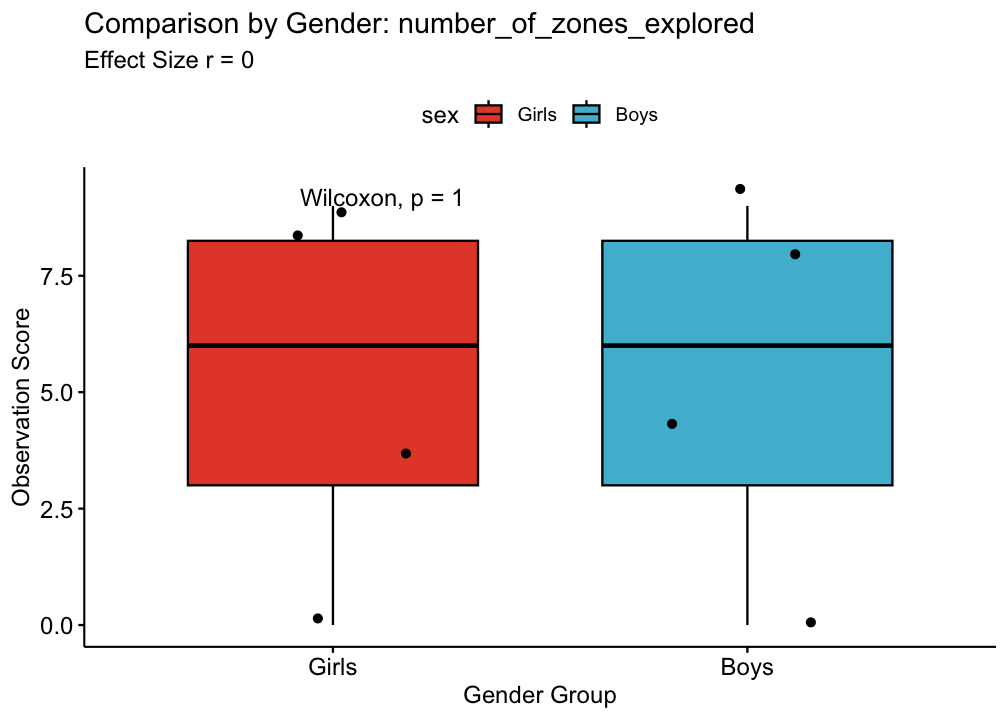

```
##
##
## ### Statistical Analysis for: movement_autonomy
## # A tibble: 1 × 7
##   .y.               group1 group2    n1    n2 statistic     p
## * <chr>             <chr>  <chr>  <int> <int>     <dbl> <dbl>
## 1 movement_autonomy Girls  Boys       5     5        10     1
## # A tibble: 1 × 7
##   .y.               group1 group2 effsize    n1    n2 magnitude
## * <chr>             <chr>  <chr>    <dbl> <int> <int> <ord>
## 1 movement_autonomy Girls  Boys     0.190     5     5 small
```

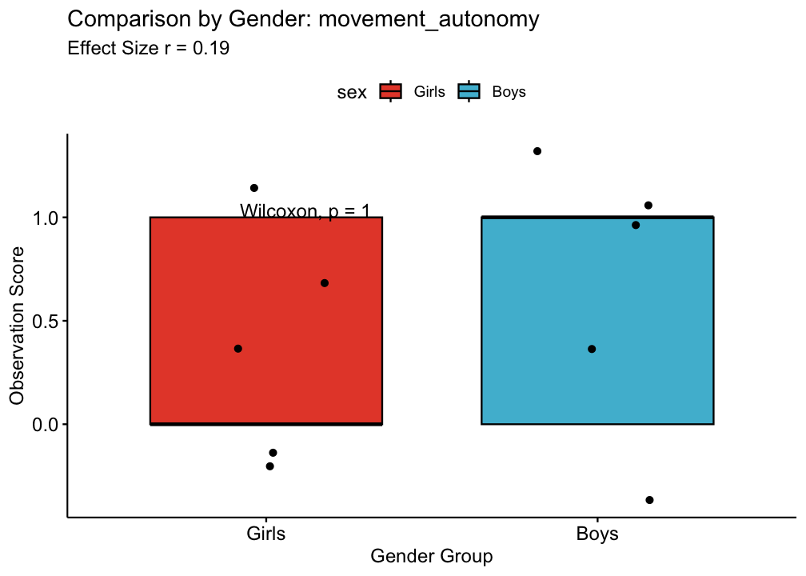

```
##
##
## ### Statistical Analysis for: orientation_towards_artwork
## # A tibble: 1 × 7
##   .y.                         group1 group2    n1    n2 statistic     p
## * <chr>                       <chr>  <chr>  <int> <int>     <dbl> <dbl>
## 1 orientation_towards_artwork Girls  Boys       5     5        15     1
## # A tibble: 1 × 7
##   .y.                         group1 group2 effsize    n1    n2 magnitude
## * <chr>                       <chr>  <chr>    <dbl> <int> <int> <ord>
## 1 orientation_towards_artwork Girls  Boys     0.190     5     5 small
```

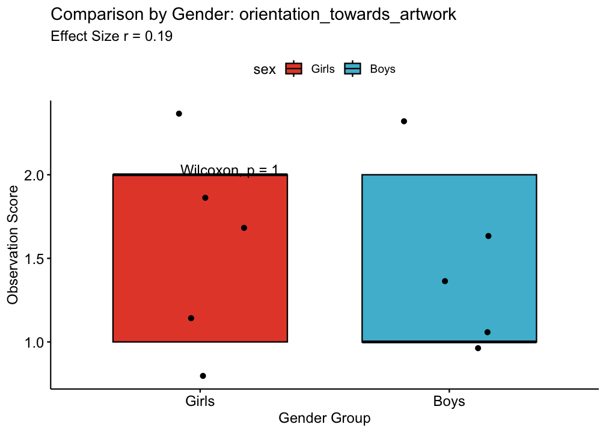

```
##
##
## ### Statistical Analysis for: postural_adjustment
## # A tibble: 1 × 7
##   .y.                 group1 group2    n1    n2 statistic     p
## * <chr>               <chr>  <chr>  <int> <int>     <dbl> <dbl>
## 1 postural_adjustment Girls  Boys       5     5         6 0.286
## # A tibble: 1 × 7
##   .y.                 group1 group2 effsize    n1    n2 magnitude
## * <chr>               <chr>  <chr>    <dbl> <int> <int> <ord>
## 1 postural_adjustment Girls  Boys     0.464     5     5 moderate
```

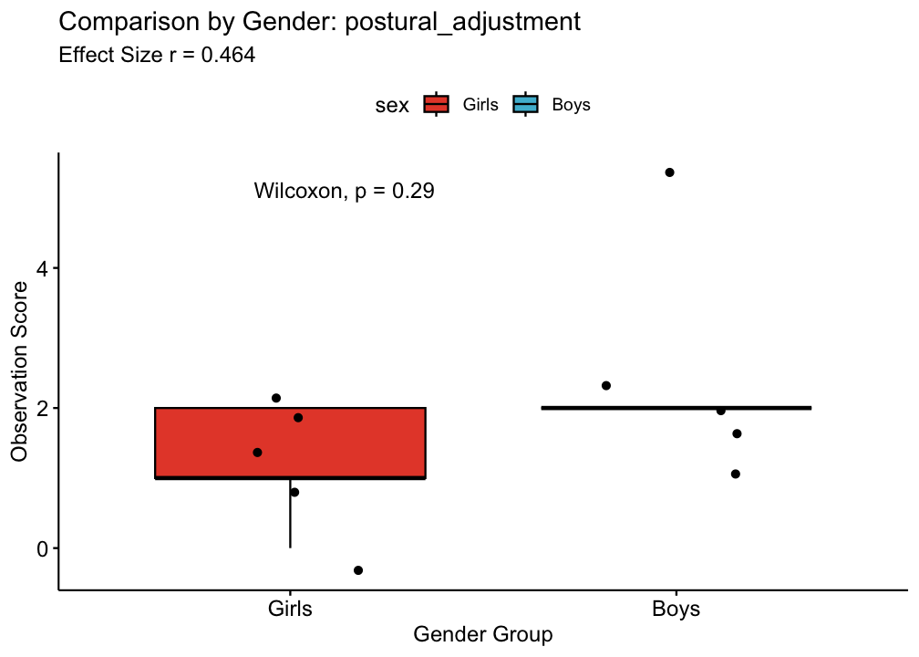

```
##
##
## ### Statistical Analysis for: overall_motor_engagement
## # A tibble: 1 × 7
##   .y.                      group1 group2    n1    n2 statistic     p
## * <chr>                    <chr>  <chr>  <int> <int>     <dbl> <dbl>
## 1 overall_motor_engagement Girls  Boys       5     5      10.5     1
## # A tibble: 1 × 7
##   .y.                      group1 group2 effsize    n1    n2 magnitude
## * <chr>                    <chr>  <chr>    <dbl> <int> <int> <ord>
## 1 overall_motor_engagement Girls  Boys     0.163     5     5 small
```

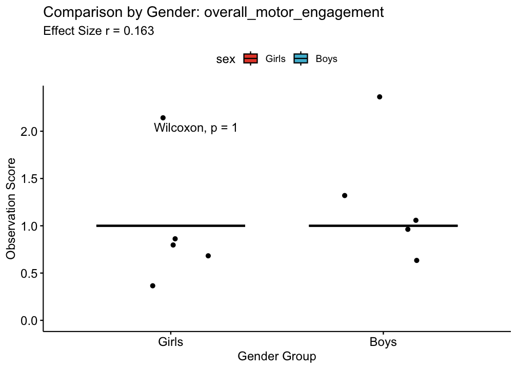

```
##
##
## ### Statistical Analysis for: interaction_with_adults
## # A tibble: 1 × 7
##   .y.                     group1 group2    n1    n2 statistic     p
## * <chr>                   <chr>  <chr>  <int> <int>     <dbl> <dbl>
## 1 interaction_with_adults Girls  Boys       4     4        11 0.486
## # A tibble: 1 × 7
##   .y.                     group1 group2 effsize    n1    n2 magnitude
## * <chr>                   <chr>  <chr>    <dbl> <int> <int> <ord>
## 1 interaction_with_adults Girls  Boys     0.331     4     4 moderate
```

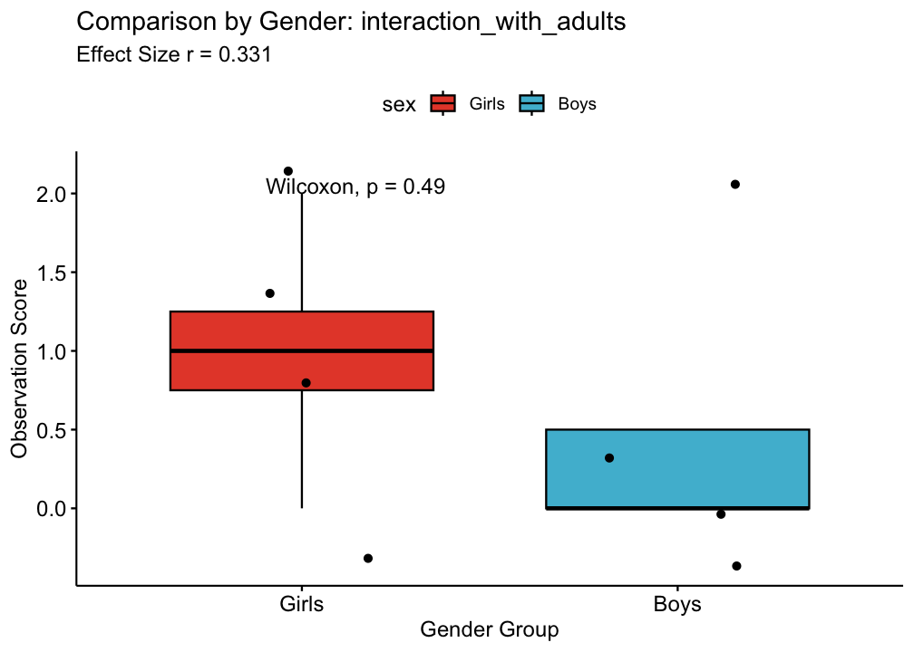

```r
# Defining the variables to analyze (Quantitative & Ordinal)
variables_to_analyze <- c("number_of_zones_explored", "movement_autonomy",
                          "orientation_towards_artwork", "postural_adjustment",
                          "overall_motor_engagement", "interaction_with_adults")

# Running the loop for statistical analysis and visualization
# We use 'v' as a placeholder for each variable in the list
for (v in variables_to_analyze) {

  cat("\n\n### Statistical Analysis for:", v, "\n")

  # 1. Wilcoxon Rank Sum Test
  # We use rstatix:: to avoid conflicts and handle non-normal data
  test_result <- df %>%
    rstatix::wilcox_test(as.formula(paste(v, "~ sex")))
  print(test_result)

  # 2. Effect Size (r)
  # Crucial for small samples (n=10) to measure the strength of the relationship
  eff_size <- df %>%
    filter(!is.na(.data[[v]])) %>%
    rstatix::wilcox_effsize(as.formula(paste(v, "~ sex")))
  print(eff_size)

  # 3. Visualization with ggboxplot
# We include jitter points to show the 10 individual observations
p <- ggboxplot(df, x = "sex", y = v,
          fill = "sex",
          palette = "npg",
          add = "jitter",
          na.rm = TRUE,
          title = paste("Comparison by Gender:", v),
          subtitle = paste("Effect Size r =", round(eff_size$effsize, 3)),
          ylab = "Observation Score",
          xlab = "Gender Group") +
  stat_compare_means(method = "wilcox.test",
                     label.y.npc = "top",
                     na.rm = TRUE)

# Display the plot in the report
print(p)

}
```

# 4.2 Global Engagement Score Creation

```r
df$global_engagement <- rowMeans(
  df[, c("movement_autonomy", "postural_adjustment", "overall_motor_engagement")],
  na.rm = TRUE
)

# We perform the test and SAVE it into 'global_test'
# We use rstatix:: to be safe from the error we saw earlier
global_test <- df %>%
  rstatix::wilcox_test(global_engagement ~ sex)
print(global_test)
```

```
## # A tibble: 1 × 7
##   .y.               group1 group2    n1    n2 statistic     p
## * <chr>             <chr>  <chr>  <int> <int>     <dbl> <dbl>
## 1 global_engagement Girls  Boys       5     5         5 0.119
```

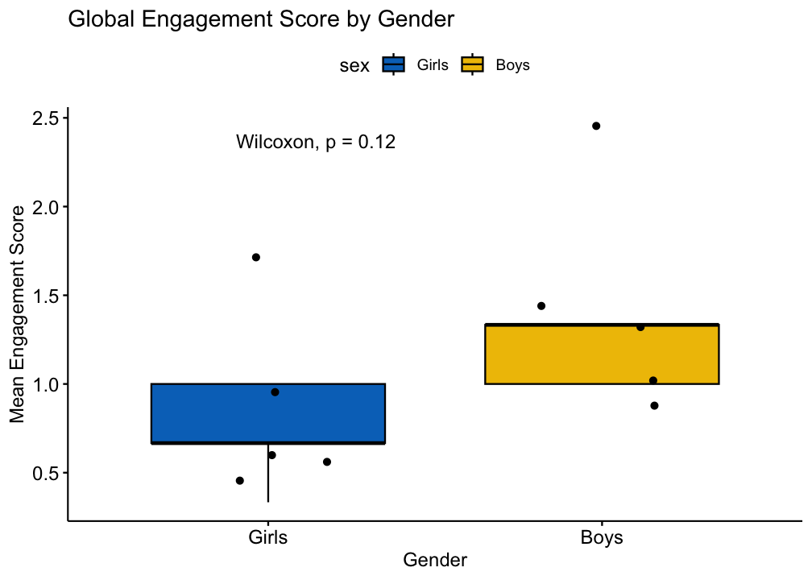

```r
# Global visualization
p_global <- ggboxplot(df, x = "sex", y = "global_engagement",
            fill = "sex", palette = "jco", add = "jitter",
            title = "Global Engagement Score by Gender",
            ylab = "Mean Engagement Score",
            xlab = "Gender") +
    stat_compare_means(method = "wilcox.test")

print(p_global)
```

### 5. Discussion

## 5.1 Statistical Summary

The objective of this analysis was to determine if gender influences children’s motor behavior and engagement at the Fabre Museum. Based on our sample of 10 observations, we can conclude the following:

- **Distribution & Test Choice:** The Shapiro-Wilk tests showed that most variables did not follow a normal distribution (p < 0.05). Consequently, we used the Wilcoxon Rank Sum test.
- **Main Results:** No statistically significant difference was found between girls and boys (p > 0.05).
- **Effect Size Insight:** We observed a moderate effect size (r ≈ 0.46) for postural adjustment, indicating a trend.

## 5.2 Scientific Interpretation

The results suggest that the museum environment acts as a “neutral” stimulus for young children. The physical interaction with the space and artworks seems to be driven more by individual curiosity than by gender-specific patterns.

## 5.3 Technical Validation

This project demonstrates a complete and reproducible data science workflow:

- **Preprocessing:** Data was cleaned and formatted using Python (Pandas).
- **Analysis:** Statistical modeling and advanced visualization were performed in R.
- **Portability:** The project uses relative paths and a standardized structure (.Rproj).

## 5.4 Limitations

The primary limitation is the sample size (N=10), which limits the power of the statistical tests. Future studies should include more subjects to confirm the trends observed.